# 2. 단어간 상관도 분석 및 시각화

```python
import warnings
warnings.filterwarnings(action='ignore')
```

```python
## 폰트 사용법
# http://corazzon.github.io/matplotlib_font_setting
```

```python
import matplotlib as mat
mat.rcParams['font.family'] = 'Malgun Gothic'
```

### ▶이번자료는

- 단어의 등장 순서를 고려하지 않는 빈도수 기반의 단어 표현 방법인 Bag of Words (TF작성) 와 상관도 계산 및 시각화 작업임

출처: https://wikidocs.net/22650

- Bag of Words란 단어들의 순서는 전혀 고려하지 않고, 단어들의 출현 빈도(frequency)에만 집중하는 텍스트 데이터의 수치화 표현 방법입니다. Bag of Words를 직역하면 단어들의 가방이라는 의미입니다. 단어들이 들어있는 가방을 상상해봅시다. 갖고있는 어떤 텍스트 문서에 있는 단어들을 가방에다가 전부 넣습니다. 그러고나서 이 가방을 흔들어 단어들을 섞습니다. 만약, 해당 문서 내에서 특정 단어가 N번 등장했다면, 이 가방에는 그 특정 단어가 N개 있게됩니다. 또한 가방을 흔들어서 단어를 섞었기 때문에 더 이상 단어의 순서는 중요하지 않습니다.

### ----------------------------------------------------------------------------------

### [Part1 -1 ]. DTM 제작 (직접 코드로 작성)

### ----------------------------------------------------------------------------------

- 이 자료는 TF-IDF의 내용과 동일함
- DTM은 데이터의 문서별 빈도수를 표시하는 Matrix

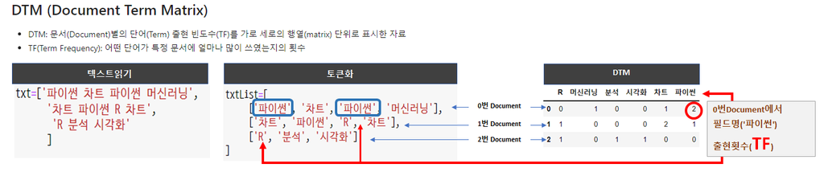

```python
def tf(t, d):
    return d.count(t)
```

```python
# 코드의 편의성을 위해서 txt자료는 빈칸단위로 분리할수 있는 자료로 준비했습니다.
import pandas as pd
txt=['파이썬 차트 파이썬 머신러닝',
      '차트 파이썬 R 차트',
       'R 분석 시각화'
      ]


vocab = list(set(w for doc in  txt for w in doc.split()))
vocab.sort()
vocab
```

```
['R', '머신러닝', '분석', '시각화', '차트', '파이썬']
```

```python
result = []
N=len(txt)
for i in range(N): # 각 문서에 대해서 아래 명령을 수행
    result.append([])
    d = txt[i]
    for j in range(len(vocab)):
        t = vocab[j]
        result[-1].append(tf(t, d))

tf_ = pd.DataFrame(result, columns = vocab)
tf_
```

|  | R | 머신러닝 | 분석 | 시각화 | 차트 | 파이썬 |
| --- | --- | --- | --- | --- | --- | --- |
| 0 | 0 | 1 | 0 | 0 | 1 | 2 |
| 1 | 1 | 0 | 0 | 0 | 2 | 1 |
| 2 | 1 | 0 | 1 | 1 | 0 | 0 |

### ----------------------------------------------------------------------------------

### [Part1 -2 ]. DTM 제작(사이킷런 제공 모듈로)

### ----------------------------------------------------------------------------------

- 사이킷런 모듈에서는 TF만을 제작하는 CountVectorizer 모듈을 제공함.
- 단 이 모듈에서 결과의 문제가 있으면 Part1-1 처럼 직접 작성하면 됨.
- 단어 Martrix DTM 제작시 비어있는 자료(0값)가 훨씬더 많은 희소(Sparse) 행렬이 됨.
- 희소행렬은 자릿수만 많이 차지하기 때문에 0값이 없는 자료만 사용하는 밀도가 높은 자료(사이킷런 CountVectorizer)를 만들어 사용하면 좋음.
- 참고: '3. 단어중요도 (TF-IDF) 및 문장유사 예측- 사이킷런 패키지 활용.html' 에 자료 있음.

#### ★★★★★★ 주의: 사이킷런 패키지에서 작성한 DTM의 문제점 ★★★★★★★★★★★

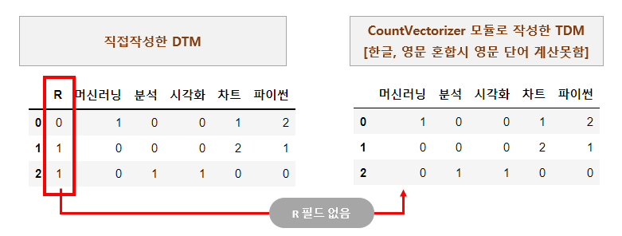

```python
txt=['파이썬 차트 파이썬 머신러닝',
      '차트 파이썬 R 차트',
       'R 분석 시각화'
      ]


from sklearn.feature_extraction.text import CountVectorizer
cv = CountVectorizer() # 일반적으로 공백을 기준으로 나눔
tdm = cv.fit_transform(txt)
tdm
```

```
<3x5 sparse matrix of type '<class 'numpy.int64'>'
	with 7 stored elements in Compressed Sparse Row format>
```

```python
# 단어목록 확인
feature=cv.get_feature_names()
print(feature)

print('\n-----tf Matrix------')
txtTDM=tdm.todense()
print(txtTDM)
```

```
['머신러닝', '분석', '시각화', '차트', '파이썬']

-----tf Matrix------
[[1 0 0 1 2]
 [0 0 0 2 1]
 [0 1 1 0 0]]
```

```python
pd.DataFrame(tdm.todense(), columns=feature)
```

|  | 머신러닝 | 분석 | 시각화 | 차트 | 파이썬 |
| --- | --- | --- | --- | --- | --- |
| 0 | 1 | 0 | 0 | 1 | 2 |
| 1 | 0 | 0 | 0 | 2 | 1 |
| 2 | 0 | 1 | 1 | 0 | 0 |

### ----------------------------------------------------------------------------------

### [Part 2 ]. 내가 직접작성하는 코드로 DTM을 제작하고 행렬화 하기

### ----------------------------------------------------------------------------------

- CountVectorizer 모듈에서 한글과 영문이 섞여있는 단어집을 DTM으로 제작할시 생기는 오류는
- 직접 DTM을 만들어서 해결.

```python
#########################
### DTM 제작
#########################


import pandas as pd
def tf(t, d):
    return d.count(t)


txt=['파이썬 차트 파이썬 머신러닝',
      '차트 파이썬 R 차트',
       'R 분석 시각화'
      ]


vocab = list(set(w for doc in  txt for w in doc.split()))
vocab.sort()


result = []
N=len(txt)
for i in range(N): # 각 문서에 대해서 아래 명령을 수행
    result.append([])
    d = txt[i]
    for j in range(len(vocab)):
        t = vocab[j]
        result[-1].append(tf(t, d))

tf_ = pd.DataFrame(result, columns = vocab)
tf_
```

|  | R | 머신러닝 | 분석 | 시각화 | 차트 | 파이썬 |
| --- | --- | --- | --- | --- | --- | --- |
| 0 | 0 | 1 | 0 | 0 | 1 | 2 |
| 1 | 1 | 0 | 0 | 0 | 2 | 1 |
| 2 | 1 | 0 | 1 | 1 | 0 | 0 |

```python
#########################
### 행렬제작
### -----tf Matrix------
## [[0 1 0 0 1 2]
## [1 0 0 0 2 1]
## [1 0 1 1 0 0]]
#########################


# DTM 데이터 프레임을 행렬로 변환함.
# 사이킷런 CountVectorizer  패키지의 txtTDM=tdm.todense()
todense=tf_.values
print(todense.shape)
print(todense)

# 레이블 보관 사이킷런 CountVectorizer  패키지의 feature=cv.get_feature_names()
feature=tf_.columns.values
print(feature)
```

```
(3, 6)
[[0 1 0 0 1 2]
 [1 0 0 0 2 1]
 [1 0 1 1 0 0]]
['R' '머신러닝' '분석' '시각화' '차트' '파이썬']
```

```python
# 사이킷런 CountVectorizer 에서는 todense.sum(axis=0))

print('\n-----총 TF구하기(열단위 집계)------')
countTDM==np.sum(todense,axis=0)
countTDM

## 해설
#     R  머신러닝  분석  시각화 차트  파이썬
# [[  0    1      0        0    1      2]
# [  1    0      0         0    2      1]
# [  1    0     1         1    0       0]]

#  세로단위 집계 R은 (0+1+1) 해서 2
```

```
-----총 TF구하기(열단위 집계)------
```

[output not shown]

### ----------------------------------------------------------------------------------

### [Part 3 ] 단어와 총 TF 묶어서 자료 만들기

### ----------------------------------------------------------------------------------

- 사이킷런의 CounVectorizer코드 (여기서는 R 글자가 안나와서 직접 코드 작성하고 있음)

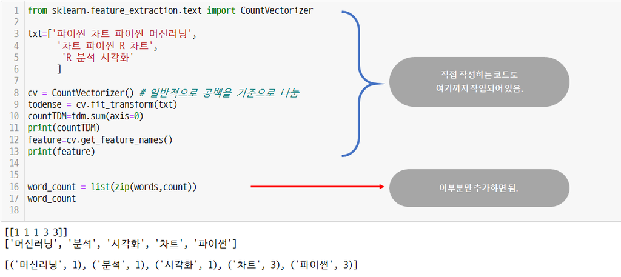

```python
#print(todense)
#print(countTDM)
#print(feature)
# 최종 결과는 어떠한 방법으로 작업해도 됨. 데이터 프레임을 행렬제작하면서 필드명하고 해서 최종결과물처럼 제작해도 됨.


print('▶ countTDM의 [[1 1 1 3 3]] 의(1,5)를 ==> [1 1 1 3 3]의 (5, ) 로 변경해야함.')
print('▶ TF의 총합인 countTDM의 shape=>')
print(np.shape(countTDM))
print(countTDM)

print('\n')
# 2차원 행렬을 1차원으로 변형, 행렬변환은 reshape도 사용되며 np.squeeze도 사용가능함.(딥러닝에서도 사용됨.)
# 또는 직접 행렬을 리스트로 옮겨도 됨.
count=np.squeeze(np.asarray(countTDM))
print('▶ TF의 총합인 변경된 countTDM의 shape=>')
print(np.shape(count))
print(count)


## feature값과 총TF값을 이용한 리스트를 작성합니다.
word_count=list(zip(feature,count))
word_count
```

[output not shown]

[output not shown]

### ----------------------------------------------------------------------------------

### [Part 4 ] 단어간 상관도 계산

### ----------------------------------------------------------------------------------

- 단어간 상관도는 데이터프레임에서 tf.corr()로 계산해도 됨.

```python
import numpy as np
# np.corrcoef(tdm.todense(),rowvar=0)  사이킷런 패키지 사용시 가능한 명령
word_corr=np.corrcoef(todense,rowvar=False)   # rowvar옵션을 0(False)와 1(True)로 하여서 행열단위의 계산 선택가능함.
word_corr
```

```
array([[ 1.       , -1.       ,  0.5      ,  0.5      ,  0.       ,
        -0.8660254],
       [-1.       ,  1.       , -0.5      , -0.5      ,  0.       ,
         0.8660254],
       [ 0.5      , -0.5      ,  1.       ,  1.       , -0.8660254,
        -0.8660254],
       [ 0.5      , -0.5      ,  1.       ,  1.       , -0.8660254,
        -0.8660254],
       [ 0.       ,  0.       , -0.8660254, -0.8660254,  1.       ,
         0.5      ],
       [-0.8660254,  0.8660254, -0.8660254, -0.8660254,  0.5      ,
         1.       ]])
```

```python
display(tf_)
tf_.corr()
```

|  | R | 머신러닝 | 분석 | 시각화 | 차트 | 파이썬 |
| --- | --- | --- | --- | --- | --- | --- |
| 0 | 0 | 1 | 0 | 0 | 1 | 2 |
| 1 | 1 | 0 | 0 | 0 | 2 | 1 |
| 2 | 1 | 0 | 1 | 1 | 0 | 0 |

|  | R | 머신러닝 | 분석 | 시각화 | 차트 | 파이썬 |
| --- | --- | --- | --- | --- | --- | --- |
| R | 1.000000 | -1.000000 | 0.500000 | 0.500000 | 0.000000 | -0.866025 |
| 머신러닝 | -1.000000 | 1.000000 | -0.500000 | -0.500000 | 0.000000 | 0.866025 |
| 분석 | 0.500000 | -0.500000 | 1.000000 | 1.000000 | -0.866025 | -0.866025 |
| 시각화 | 0.500000 | -0.500000 | 1.000000 | 1.000000 | -0.866025 | -0.866025 |
| 차트 | 0.000000 | 0.000000 | -0.866025 | -0.866025 | 1.000000 | 0.500000 |
| 파이썬 | -0.866025 | 0.866025 | -0.866025 | -0.866025 | 0.500000 | 1.000000 |

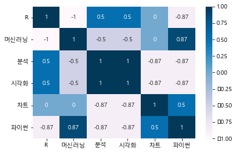

```python
# R과 머신러닝이 -1 의 상관도임
# R이라는 글자가 나올때는 머신러닝이라는 글자가 전혀 나오지 않는다는 뜻
import seaborn as sns
sns.heatmap(tf_.corr(),annot=True,cmap = 'PuBu')
```

```python
word_corr[0]   # 0번째 R값의 모든 상관도 표시
```

```
array([ 1.       , -1.       ,  0.5      ,  0.5      ,  0.       ,
       -0.8660254])
```

```python
### 단어의 집합별 상관계수 값 리스트화 하기

words=feature
edges = []

for i in range(len(words)):
    for j in range(i+1, len(words)):
        edges.append((words[i],words[j], word_corr[i,j]))
```

```python
edges
```

```
[('R', '머신러닝', -1.0),
 ('R', '분석', 0.4999999999999999),
 ('R', '시각화', 0.4999999999999999),
 ('R', '차트', 0.0),
 ('R', '파이썬', -0.8660254037844385),
 ('머신러닝', '분석', -0.5),
 ('머신러닝', '시각화', -0.5),
 ('머신러닝', '차트', 0.0),
 ('머신러닝', '파이썬', 0.8660254037844387),
 ('분석', '시각화', 0.9999999999999998),
 ('분석', '차트', -0.8660254037844385),
 ('분석', '파이썬', -0.8660254037844385),
 ('시각화', '차트', -0.8660254037844385),
 ('시각화', '파이썬', -0.8660254037844385),
 ('차트', '파이썬', 0.5)]
```

```python
# 상관도 내림차순순으로 sort(reverse=True)
# 상관도 오름차순순으로 sort(reverse=False)
edges = sorted(edges, key=lambda x:x[2],reverse=True)
edges[:5] #상관도 높은 상위 5개 자료보기
```

```
[('분석', '시각화', 0.9999999999999998),
 ('머신러닝', '파이썬', 0.8660254037844387),
 ('차트', '파이썬', 0.5),
 ('R', '분석', 0.4999999999999999),
 ('R', '시각화', 0.4999999999999999)]
```